# Exam 2

Last complied on April 22, 2026

## Electronic Arts

Electronic Arts Inc. (EA) is a California-based video game company which, in terms of revenue, is the second-largest gaming company in the Americas and Europe. Notable games created by EA include Apex Legends, Sims, Star Wars Battlefront and the EA Sports suite of games (FIFA, NBA Live, etc.). With every new game released, a large amount of revenue is generated by “pre-orders” in which a customer purchases the game in advance of the release date to ensure they receive their copy as soon as it becomes available. On November 17, 2017 Star Wars Battlefront II was released. Prior to this release EA experimented with the pre-order promotional banner shown on their website. In particular they altered the location of the promotional banner, whether the banner was a photo or video, whether the banner showed the game’s price, whether the banner advertised the game’s downloadable content (i.e., purchasable expansions that provide additional/ enriched gameplay), and whether the banner offered a “Pre-Order Now” 10% discount. The experimental factors and their levels are summarized in the following table:

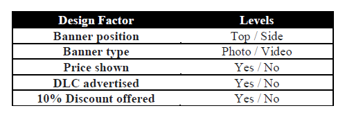

A total of 32 experimental conditions (banners) were created from the 32 unique combinations of the factor levels, and each banner was shown separately to 500 different randomly selected visitors to www.ea.com. For each of these customers, their purchase total (the total dollars spent during their visit to the website) was recorded. Interest lies in determining which banner maximizes average-purchase-total and understanding which of the investigated factor(s) significantly drive pre-order purchases. Below is the `head()` of the data.

```r
library(tidyverse)
ea<-read.csv("I:\\Classes\\ISA 633\\Exams\\Spring 2026\\Exam 2\\ea.csv")
head(ea)
```

```
##   banner.position banner.type price.shown dlc.advertised discount spend
## 1               1          -1           1              1       -1 47.93
## 2              -1          -1           1              1       -1 36.82
## 3              -1           1          -1              1       -1 45.94
## 4               1          -1           1              1       -1 46.00
## 5              -1           1          -1             -1        1 46.42
## 6               1           1           1              1        1 56.99
```

```r
glimpse(ea)
```

```
## Rows: 16,000
## Columns: 6
## $ banner.position <int> 1, -1, -1, 1, -1, 1, 1, -1, 1, -1, 1, 1, 1, 1, 1, -1, …
## $ banner.type     <int> -1, -1, 1, -1, 1, 1, -1, 1, -1, -1, 1, 1, 1, 1, -1, 1,…
## $ price.shown     <int> 1, 1, -1, 1, -1, 1, -1, -1, -1, -1, -1, 1, 1, 1, -1, 1…
## $ dlc.advertised  <int> 1, 1, 1, 1, -1, 1, -1, 1, 1, -1, 1, -1, 1, 1, -1, 1, 1…
## $ discount        <int> -1, -1, -1, -1, 1, 1, -1, 1, 1, 1, 1, 1, -1, -1, 1, -1…
## $ spend           <dbl> 47.93, 36.82, 45.94, 46.00, 46.42, 56.99, 46.97, 44.94…
```

Re-label factors for easy-to-read output.

```r
ea$A<-ea$banner.position
ea$B<-ea$banner.type
ea$C<-ea$price.shown
ea$D<-ea$dlc.advertised
ea$E<-ea$discount
```

Model 1:

```r
reg<-lm(spend~A*B*C*D*E, data=ea)
summary(reg)
```

```
##
## Call:
## lm(formula = spend ~ A * B * C * D * E, data = ea)
##
## Residuals:
##     Min      1Q  Median      3Q     Max
## -3.9786 -0.6700 -0.0010  0.6778  3.7917
##
## Coefficients:
##               Estimate Std. Error  t value Pr(>|t|)
## (Intercept)  4.500e+01  7.907e-03 5691.170   <2e-16 ***
## A            4.998e+00  7.907e-03  632.154   <2e-16 ***
## B            5.000e+00  7.907e-03  632.311   <2e-16 ***
## C            1.113e-02  7.907e-03    1.408   0.1592
## D            1.599e-02  7.907e-03    2.023   0.0431 *
## E           -7.355e-03  7.907e-03   -0.930   0.3523
## A:B          2.693e-03  7.907e-03    0.341   0.7335
## A:C         -4.589e-03  7.907e-03   -0.580   0.5617
## B:C          4.414e-03  7.907e-03    0.558   0.5767
## A:D          8.093e-03  7.907e-03    1.023   0.3061
## B:D         -1.362e-02  7.907e-03   -1.722   0.0851 .
## C:D         -8.737e-04  7.907e-03   -0.111   0.9120
## A:E         -6.111e-03  7.907e-03   -0.773   0.4396
## B:E          9.987e-01  7.907e-03  126.310   <2e-16 ***
## C:E          4.960e-03  7.907e-03    0.627   0.5305
## D:E         -1.176e-03  7.907e-03   -0.149   0.8817
## A:B:C        4.150e-03  7.907e-03    0.525   0.5997
## A:B:D       -2.791e-03  7.907e-03   -0.353   0.7241
## A:C:D       -5.622e-03  7.907e-03   -0.711   0.4770
## B:C:D        1.025e-03  7.907e-03    0.130   0.8969
## A:B:E       -9.057e-03  7.907e-03   -1.146   0.2520
## A:C:E       -5.304e-03  7.907e-03   -0.671   0.5024
## B:C:E       -1.280e-02  7.907e-03   -1.619   0.1055
## A:D:E       -1.014e-02  7.907e-03   -1.283   0.1995
## B:D:E        7.378e-03  7.907e-03    0.933   0.3508
## C:D:E       -7.109e-03  7.907e-03   -0.899   0.3686
## A:B:C:D      9.189e-03  7.907e-03    1.162   0.2452
## A:B:C:E     -2.550e-04  7.907e-03   -0.032   0.9743
## A:B:D:E     -6.375e-05  7.907e-03   -0.008   0.9936
## A:C:D:E     -5.110e-03  7.907e-03   -0.646   0.5181
## B:C:D:E     -6.660e-03  7.907e-03   -0.842   0.3996
## A:B:C:D:E   -4.269e-03  7.907e-03   -0.540   0.5893
## ---
## Signif. codes:  0 '***' 0.001 '**' 0.01 '*' 0.05 '.' 0.1 ' ' 1
##
## Residual standard error: 1 on 15968 degrees of freedom
## Multiple R-squared:  0.9808, Adjusted R-squared:  0.9808
## F-statistic: 2.63e+04 on 31 and 15968 DF,  p-value: < 2.2e-16
```

Model 2:

```r
reg<-lm(spend~A*B*C*D*E-A:B:D-D:E-B:C:D-A:B:C:E-A:B:D:E-C:D-A:B-A:B:C:D:E-B:C-A:B:C-A:C-A:C:D:E-A:C:E-A:C:D-C:E-B:C:D:E-C:D:E-B:D:E-A:E-A:B:E-A:D-A:B:C:D-A:D:E-B:C:E-C-B:D, data=ea)
summary(reg)
```

```
##
## Call:
## lm(formula = spend ~ A * B * C * D * E - A:B:D - D:E - B:C:D -
##     A:B:C:E - A:B:D:E - C:D - A:B - A:B:C:D:E - B:C - A:B:C -
##     A:C - A:C:D:E - A:C:E - A:C:D - C:E - B:C:D:E - C:D:E - B:D:E -
##     A:E - A:B:E - A:D - A:B:C:D - A:D:E - B:C:E - C - B:D, data = ea)
##
## Residuals:
##     Min      1Q  Median      3Q     Max
## -3.9438 -0.6726 -0.0026  0.6762  3.7846
##
## Coefficients:
##              Estimate Std. Error  t value Pr(>|t|)
## (Intercept) 44.999923   0.007905 5692.382   <2e-16 ***
## A            4.998424   0.007905  632.289   <2e-16 ***
## B            4.999669   0.007905  632.446   <2e-16 ***
## D            0.015994   0.007905    2.023   0.0431 *
## E           -0.007355   0.007905   -0.930   0.3522
## B:E          0.998726   0.007905  126.336   <2e-16 ***
## ---
## Signif. codes:  0 '***' 0.001 '**' 0.01 '*' 0.05 '.' 0.1 ' ' 1
##
## Residual standard error: 0.9999 on 15994 degrees of freedom
## Multiple R-squared:  0.9808, Adjusted R-squared:  0.9808
## F-statistic: 1.631e+05 on 5 and 15994 DF,  p-value: < 2.2e-16
```

Check assumptions:

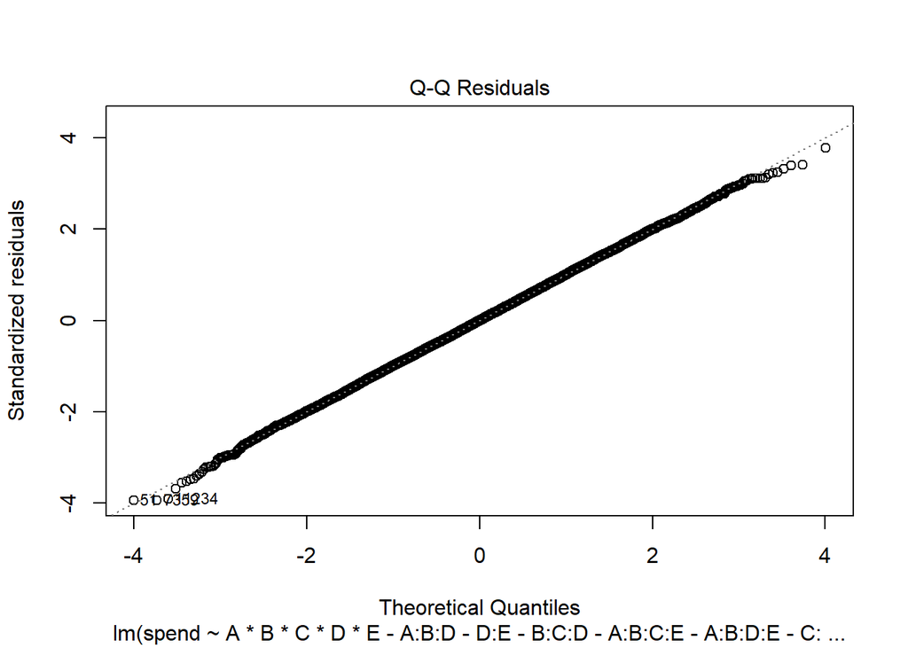

```r
plot(reg, which=2)
```

Interaction Plot:

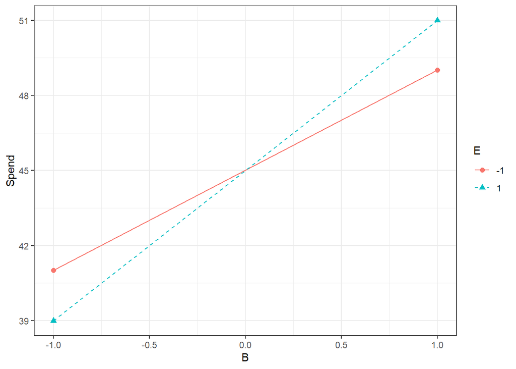

```r
library(ggeffects)
library(ggplot2)

eff <- ggpredict(reg, terms = c("B", "E"))
eff_df<-as.data.frame(eff)
eff_df$B <- eff_df$x
eff_df$E <- eff_df$group

ggplot(eff_df,
       aes(x = x, y = predicted,
           group = E, linetype = E, shape = E, color=E)) +
  geom_point(size = 2) +
  geom_line(aes(color = E)) +
  #facet_wrap(C~D, labeller = label_both) +
  scale_linetype_manual(values = c("solid", "dashed")) +
  labs(
    x = "B",
    y = "Spend",
    #linetype = NULL,
    #shape = NULL
  ) +
  theme_bw()
```

## Course Hero

Course Hero is an education technology company which hosts an online repository of course-specific study resources for tens of thousands of courses at post-secondary institutions. Complete access is blocked by a “paywall” and is only available to paying subscribers. Given that Course Hero is a for-profit company, interest lies in maximizing the conversion rate from “free” to “premium” accounts. As such an experiment is conducted which alters various aspects of the “premium” service to determine which offer maximizes conversion rates. In particular, when a user visits the pricing webpage, they are offered one of 12 versions of the “premium” services. The different versions are based on differing values of the price ($9.95/month or $10/month), the number of Tutor Questions they are permitted to ask (10, 20 or 40) and whether a 6-month free trial is offered (Yes or No). Each of these 12 versions is separately offered to 1000 different randomly selected users currently subscribed to the “free” tier. For each user in the experiment the binary indicator convert/non-convert is recorded.

Here is the data.

```r
ch<-read.csv("I:\\Classes\\ISA 633\\Exams\\Spring 2026\\Exam 2\\coursehero.csv")
ch$reps<-rep(1000, 12)
ch
```

```
##    price tutor free_trial conversion reps
## 1  10.00    20         No        199 1000
## 2  10.00    40         No        217 1000
## 3   9.95    10        Yes        206 1000
## 4  10.00    10         No        219 1000
## 5   9.95    10         No        221 1000
## 6  10.00    40        Yes        220 1000
## 7   9.95    20        Yes        225 1000
## 8   9.95    40         No        232 1000
## 9  10.00    10        Yes        205 1000
## 10  9.95    20         No        254 1000
## 11  9.95    40        Yes        237 1000
## 12 10.00    20        Yes        211 1000
```

Analysis 1:

```r
mod<-aov(conversion~price*tutor*free_trial, data=ch)
summary(mod)
```

```
##                        Df Sum Sq Mean Sq F value Pr(>F)
## price                   1  901.3   901.3   4.280  0.107
## tutor                   1  334.3   334.3   1.588  0.276
## free_trial              1  120.3   120.3   0.571  0.492
## price:tutor             1   37.1    37.1   0.176  0.696
## price:free_trial        1  133.3   133.3   0.633  0.471
## tutor:free_trial        1  178.1   178.1   0.846  0.410
## price:tutor:free_trial  1   18.0    18.0   0.086  0.785
## Residuals               4  842.4   210.6
```

Analysis 2:

```r
mod<-glm(cbind(conversion, reps-conversion)~price*tutor*free_trial, data=ch, family="binomial")
anova(mod, test="Chisq")
```

```
## Analysis of Deviance Table
##
## Model: binomial, link: logit
##
## Response: cbind(conversion, reps - conversion)
##
## Terms added sequentially (first to last)
##
##
##                        Df Deviance Resid. Df Resid. Dev Pr(>Chi)
## NULL                                      11    14.7839
## price                   1   5.2451        10     9.5389  0.02201 *
## tutor                   1   1.9420         9     7.5969  0.16346
## free_trial              1   0.7005         8     6.8964  0.40260
## price:tutor             1   0.1804         7     6.7160  0.67105
## price:free_trial        1   0.7360         6     5.9800  0.39093
## tutor:free_trial        1   1.0683         5     4.9117  0.30134
## price:tutor:free_trial  1   0.0968         4     4.8148  0.75564
## ---
## Signif. codes:  0 '***' 0.001 '**' 0.01 '*' 0.05 '.' 0.1 ' ' 1
```

Analysis 3:

```r
mod<-aov(conversion~price*tutor*free_trial, data=ch)
summary(mod)
```

```
##                        Df Sum Sq Mean Sq
## price                   1  901.3   901.3
## tutor                   2  396.5   198.3
## free_trial              1  120.3   120.3
## price:tutor             2  547.2   273.6
## price:free_trial        1  133.3   133.3
## tutor:free_trial        2  178.2    89.1
## price:tutor:free_trial  2  288.2   144.1
```

Analysis 4:

```r
mod<-glm(cbind(conversion, reps-conversion)~price*tutor*free_trial, data=ch, family="binomial")
anova(mod, test="Chisq")
```

```
## Analysis of Deviance Table
##
## Model: binomial, link: logit
##
## Response: cbind(conversion, reps - conversion)
##
## Terms added sequentially (first to last)
##
##
##                        Df Deviance Resid. Df Resid. Dev Pr(>Chi)
## NULL                                      11    14.7839
## price                   1   5.2451        10     9.5389  0.02201 *
## tutor                   2   2.3143         8     7.2246  0.31438
## free_trial              1   0.7006         7     6.5240  0.40259
## price:tutor             2   3.1204         5     3.4036  0.21010
## price:free_trial        1   0.7365         4     2.6672  0.39079
## tutor:free_trial        2   1.0746         2     1.5926  0.58432
## price:tutor:free_trial  2   1.5926         0     0.0000  0.45100
## ---
## Signif. codes:  0 '***' 0.001 '**' 0.01 '*' 0.05 '.' 0.1 ' ' 1
```

## Design Comparison

Design 1:

```r
library(FrF2)
d<-FrF2(32, 6)
d
```

```
##     A  B  C  D  E  F
## 1  -1  1 -1 -1  1 -1
## 2  -1 -1 -1 -1  1  1
## 3   1  1 -1  1 -1  1
## 4   1 -1  1  1  1 -1
## 5   1 -1  1 -1 -1 -1
## 6   1  1 -1  1  1 -1
## 7  -1  1 -1 -1 -1  1
## 8  -1  1 -1  1  1  1
## 9   1 -1 -1  1 -1 -1
## 10  1 -1  1  1 -1  1
## 11 -1 -1 -1  1  1 -1
## 12  1  1  1  1 -1 -1
## 13  1  1  1 -1 -1  1
## 14 -1  1  1 -1  1  1
```

[output cut: 19 more lines]

```r
d$y<-rnorm(32)
aliases(lm(y~(.)^4, data=d))
```

```
##
##  A:B = C:D:E:F
##  A:C = B:D:E:F
##  A:D = B:C:E:F
##  A:E = B:C:D:F
##  A:F = B:C:D:E
##  B:C = A:D:E:F
##  B:D = A:C:E:F
##  B:E = A:C:D:F
##  B:F = A:C:D:E
##  C:D = A:B:E:F
##  C:E = A:B:D:F
##  C:F = A:B:D:E
##  D:E = A:B:C:F
##  D:F = A:B:C:E
##  E:F = A:B:C:D
##  A:B:C = D:E:F
##  A:B:D = C:E:F
##  A:B:E = C:D:F
##  A:B:F = C:D:E
##  A:C:D = B:E:F
##  A:C:E = B:D:F
##  A:C:F = B:D:E
##  A:D:E = B:C:F
##  A:D:F = B:C:E
##  A:E:F = B:C:D
```

Design 2:

```r
library(FrF2)
d<-FrF2(16, 6)
d
```

```
##     A  B  C  D  E  F
## 1   1 -1  1 -1 -1  1
## 2   1 -1 -1  1  1 -1
## 3  -1  1 -1  1  1 -1
## 4  -1 -1  1  1  1  1
## 5  -1  1  1  1 -1 -1
## 6   1 -1 -1 -1  1  1
## 7   1  1 -1 -1 -1 -1
## 8  -1  1 -1 -1  1  1
## 9  -1 -1 -1  1 -1  1
## 10  1  1  1 -1  1 -1
## 11 -1 -1 -1 -1 -1 -1
## 12 -1  1  1 -1 -1  1
## 13  1  1 -1  1 -1  1
## 14  1  1  1  1  1  1
## 15 -1 -1  1 -1  1 -1
## 16  1 -1  1  1 -1 -1
## class=design, type= FrF2
```

```r
d$y<-rnorm(16)
aliases(lm(y~(.)^4, data=d))
```

```
##
##  A = B:C:E = B:D:F
##  B = A:D:F = A:C:E
##  C = D:E:F = A:B:E
##  D = C:E:F = A:B:F
##  E = C:D:F = A:B:C
##  F = C:D:E = A:B:D
##  A:B = C:E = D:F
##  A:C = A:D:E:F = B:C:D:F = B:E
##  A:D = A:C:E:F = B:C:D:E = B:F
##  A:E = A:C:D:F = B:D:E:F = B:C
##  A:F = A:C:D:E = B:C:E:F = B:D
##  C:D = A:B:C:F = A:B:D:E = E:F
##  C:F = A:B:C:D = A:B:E:F = D:E
##  A:C:D = A:E:F = B:C:F = B:D:E
##  A:C:F = A:D:E = B:C:D = B:E:F
```

## e-Commerce Company

A large e-commerce company is seeking to improve the efficiency of its warehouse operations by reducing the average time required to fulfill customer orders. To do this, the company conducts a designed experiment in one of its fulfillment centers, evaluating seven operational factors that may influence performance, including staffing levels (A), picking methods (B), conveyor speed (C), packing resources (D), routing algorithms (E), shift timing (F), and inventory layout (G). Because testing all possible combinations would be too costly and disruptive, the company implements a fractional factorial design that allows it to efficiently study the effects of these factors over a limited number of experimental runs. Each experimental condition is replicated across three time periods (e.g., different shifts) to account for natural variability in order volume and worker performance. During each run, the warehouse operates under a specific combination of factor settings for a fixed time period, and the response is measured as the average order fulfillment time (in minutes per order). The goal of the experiment is to identify which factors have the greatest impact on processing time (lower is better) while obtaining reliable estimates of variability to support statistical inference and decision-making.

Below is the treatment combinations they used an the alias structure.

```r
d<-FrF2(16, 7, randomze=FALSE)
d
```

```
##     A  B  C  D  E  F  G
## 1  -1  1 -1  1  1 -1  1
## 2   1  1 -1  1 -1  1 -1
## 3   1  1  1  1  1  1  1
## 4  -1 -1  1  1  1  1 -1
## 5  -1  1  1  1 -1 -1 -1
## 6  -1 -1  1 -1  1 -1  1
## 7  -1  1  1 -1 -1  1  1
## 8  -1 -1 -1 -1 -1 -1 -1
## 9   1 -1 -1 -1  1  1  1
## 10  1  1 -1 -1 -1 -1  1
## 11  1 -1 -1  1  1 -1 -1
## 12  1  1  1 -1  1 -1 -1
## 13  1 -1  1 -1 -1  1 -1
## 14  1 -1  1  1 -1 -1  1
## 15 -1 -1 -1  1 -1  1  1
## 16 -1  1 -1 -1  1  1 -1
## class=design, type= FrF2
```

```r
d$y<-rnorm(16)
aliases( lm( y~ (.)^3, data = d))
```

```
##
##  A = B:C:E = B:D:F = C:D:G = E:F:G
##  B = A:C:E = A:D:F = C:F:G = D:E:G
##  C = A:D:G = B:F:G = D:E:F = A:B:E
##  D = A:C:G = B:E:G = C:E:F = A:B:F
##  E = A:F:G = B:D:G = C:D:F = A:B:C
##  F = A:E:G = B:C:G = C:D:E = A:B:D
##  G = A:C:D = A:E:F = B:C:F = B:D:E
##  A:B = C:E = D:F
##  A:C = B:E = D:G
##  A:D = B:F = C:G
##  A:E = B:C = F:G
##  A:F = B:D = E:G
##  A:G = C:D = E:F
##  B:G = C:F = D:E
##  A:B:G = A:C:F = A:D:E = B:C:D = B:E:F = C:E:G = D:F:G
```

Initial model.

```r
reg<-lm(y ~ A+B+C+D+E+F+G+A:B+A:C+A:D+A:E+A:F+A:G +B:G+A:B:G, data = d)
summary(reg)
```

```
##
## Call:
## lm.default(formula = y ~ A + B + C + D + E + F + G + A:B + A:C +
##     A:D + A:E + A:F + A:G + B:G + A:B:G, data = d)
##
## Residuals:
##      Min       1Q   Median       3Q      Max
## -2.04348 -0.54389  0.00693  0.49561  1.59804
##
## Coefficients:
##               Estimate Std. Error t value Pr(>|t|)
## (Intercept)  2.9373659  0.1358138  21.628  < 2e-16 ***
## A           -0.1145710  0.1358138  -0.844   0.4052
## B            1.2982530  0.1358138   9.559 6.75e-11 ***
## C            1.0347270  0.1358138   7.619 1.11e-08 ***
## D           -0.0691760  0.1358138  -0.509   0.6140
## E            0.1619169  0.1358138   1.192   0.2419
## F            0.9127380  0.1358138   6.721 1.37e-07 ***
## G            1.2337611  0.1358138   9.084 2.25e-10 ***
## A:B          0.1768868  0.1358138   1.302   0.2021
## A:C         -0.2541936  0.1358138  -1.872   0.0704 .
## A:D         -0.1382280  0.1358138  -1.018   0.3164
## A:E         -0.0009176  0.1358138  -0.007   0.9947
## A:F          0.1102944  0.1358138   0.812   0.4227
## A:G          0.0498524  0.1358138   0.367   0.7160
## B:G          1.0742393  0.1358138   7.910 5.01e-09 ***
## A:B:G        0.0495510  0.1358138   0.365   0.7176
## ---
## Signif. codes:  0 '***' 0.001 '**' 0.01 '*' 0.05 '.' 0.1 ' ' 1
##
## Residual standard error: 0.9409 on 32 degrees of freedom
## Multiple R-squared:  0.9161, Adjusted R-squared:  0.8767
## F-statistic: 23.28 on 15 and 32 DF,  p-value: 4.874e-13
```

Final model.

```r
reg<-lm(y ~A+ B+C+F+G+B:G, data = d)
summary(reg)
```

[output not shown]

## Bayesian Analayis

### Scenario 1:

In an A/B test with a binary response of convert or not, we assume the true proportion of arm $a$ will behave according to the following distribution, which is updated as the data for the test arrives.

$$p_a|\text{data} \sim
\text{Beta}(a_a+s_a, b_a+f_a)$$
We will use $\text{Beta}(1,1)$ as the prior distribution.

### Scenario 2:

In an A/B test with a continuous response, average spend per day, we assume the mean behaves according to the following distribution, which is updated as the data for the test arrives.

$$\mu_a|data \sim N(m_a, s^2_a)$$
and where

$$s^2_a=(\frac{1}{s^2_0}+\frac{n_a}{\sigma^2})^{-1}$$

$$m_a=s^2_a(\frac{m_0}{s^2_0}+\frac{n_a\bar{y}_a}{\sigma^2})$$
We will use this prior distribution
$$\mu_a \sim N(m_0, s^2_0)$$
for arm $a$ and assume $s_0$=10 and $m_0$=0. From historical data we know $\sigma^2=5$.

## Ridesharing Company

A Ridesharing company is comparing a new dynamic pricing algorithm (B) to its current pricing system (A). Twenty regions are randomly assigned to sequences AB or BA, where each region uses one algorithm in week 1 and the other in week 2. The response is average revenue per ride-hour. A reset between weeks minimizes carryover effects.

```r
rs<-read.csv("I:\\Classes\\ISA 633\\Exams\\Spring 2026\\Exam 2\\ridesharing.csv")
rs
```

```
##    Region Sequence Algorithm_A Algorithm_B
## 1     R01       AB    47.62466    52.71540
## 2     R02       AB    44.72172    48.47720
## 3     R03       AB    47.12813    50.53385
## 4     R04       AB    49.96928    51.40051
## 5     R05       AB    42.40624    48.89336
## 6     R06       AB    43.31671    50.46330
## 7     R07       AB    49.97448    53.32944
## 8     R08       AB    48.95457    53.91624
## 9     R09       AB    43.76918    47.44991
## 10    R10       AB    44.78331    50.21645
## 11    R11       BA    43.76694    47.46932
## 12    R12       BA    42.90785    52.30878
## 13    R13       BA    45.03456    50.28498
## 14    R14       BA    39.03753    43.20030
## 15    R15       BA    40.19999    41.47066
## 16    R16       BA    44.14953    46.80910
## 17    R17       BA    40.44803    46.35196
## 18    R18       BA    45.72881    47.49752
## 19    R19       BA    42.21943    44.57257
## 20    R20       BA    41.22759    42.44746
```

```r
rs$diff <- ifelse(
  rs$Sequence == "AB",
  0.5 * (rs$Algorithm_A- rs$Algorithm_B),
  0.5 * (rs$Algorithm_B- rs$Algorithm_A)  #mu_A-mu_B
)
```

```r
t.test(diff ~ Sequence, data = rs, var.equal=TRUE)
```

```
##
##  Two Sample t-test
##
## data:  diff by Sequence
## t = -8.5263, df = 18, p-value = 9.776e-08
## alternative hypothesis: true difference in means between group AB and group BA is not equal to 0
## 95 percent confidence interval:
##  -5.137663 -3.106312
## sample estimates:
## mean in group AB mean in group BA
##        -2.237369         1.884619
```